# Assignment2

Sricharraan Ramaswamy

24/01/2022

```r
library(tidyverse)
```

```r
library(ggplot2)
```

```r
cytof <- read.csv("cytof_one_experiment.csv")

mean = cytof %>% pivot_longer(colnames(cytof), names_to = "markers", values_to = "observations") %>% group_by(markers) %>% summarise(mean = mean(observations))
mean
```

```
## # A tibble: 35 × 2
##    markers  mean
##    <chr>   <dbl>
##  1 CD107a  0.608
##  2 CD16    4.95
##  3 CD161   1.06
##  4 CD2     3.41
##  5 CD4     0.287
##  6 CD56    5.72
##  7 CD57    2.58
##  8 CD69    4.51
##  9 CD8     2.21
## 10 CXCR6   0.547
## # … with 25 more rows
```

```r
median = cytof %>% pivot_longer(colnames(cytof), names_to = "markers", values_to = "observations") %>% group_by(markers) %>% summarise(median = median(observations))
median
```

```
## # A tibble: 35 × 2
##    markers  median
##    <chr>     <dbl>
##  1 CD107a  -0.122
##  2 CD16     5.12
##  3 CD161    0.726
##  4 CD2      3.95
##  5 CD4     -0.204
##  6 CD56     5.71
##  7 CD57     3.07
##  8 CD69     4.59
##  9 CD8      2.40
## 10 CXCR6   -0.0581
## # … with 25 more rows
```

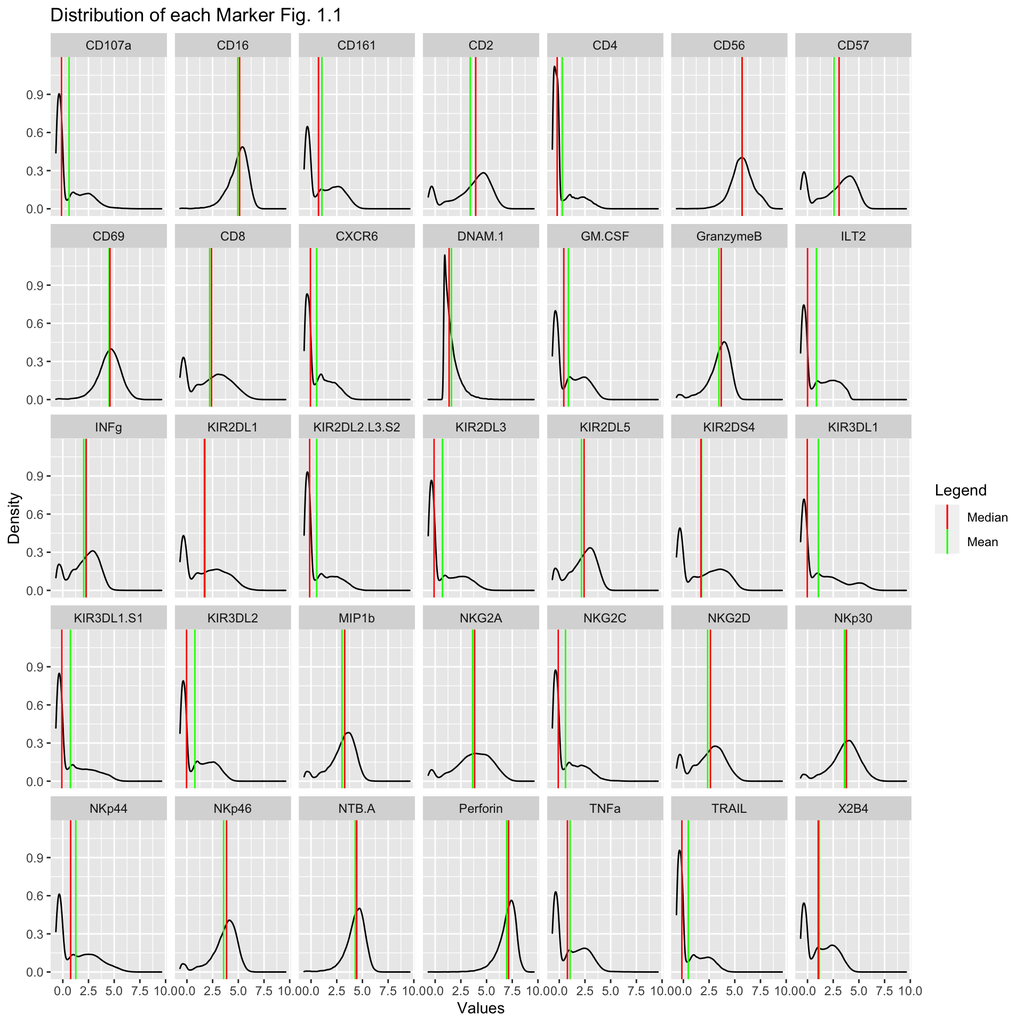

```r
cytof %>% pivot_longer(colnames(cytof), names_to = "markers", values_to = "observations") %>% ggplot(aes(x = observations)) +
  geom_density() +
  facet_wrap(~markers,ncol = 7)+
  geom_vline( data = mean,aes(xintercept = mean,color = 'Mean'))+
  geom_vline( data = median,aes(xintercept = median,color = 'Median'))+
  scale_color_manual(name = 'Legend', values = c ('Median' = 'red', 'Mean' ='green')) +
  xlab("Values") + ylab("Density")+ ggtitle('Distribution of each Marker Fig. 1.1')
```

After plotting the graphs of each markers we can clearly see that some of them are right skewed some are left skewed and some follow normal distribution whereas some are no distribution at all. There are some markers which are somilar.

## Question 2

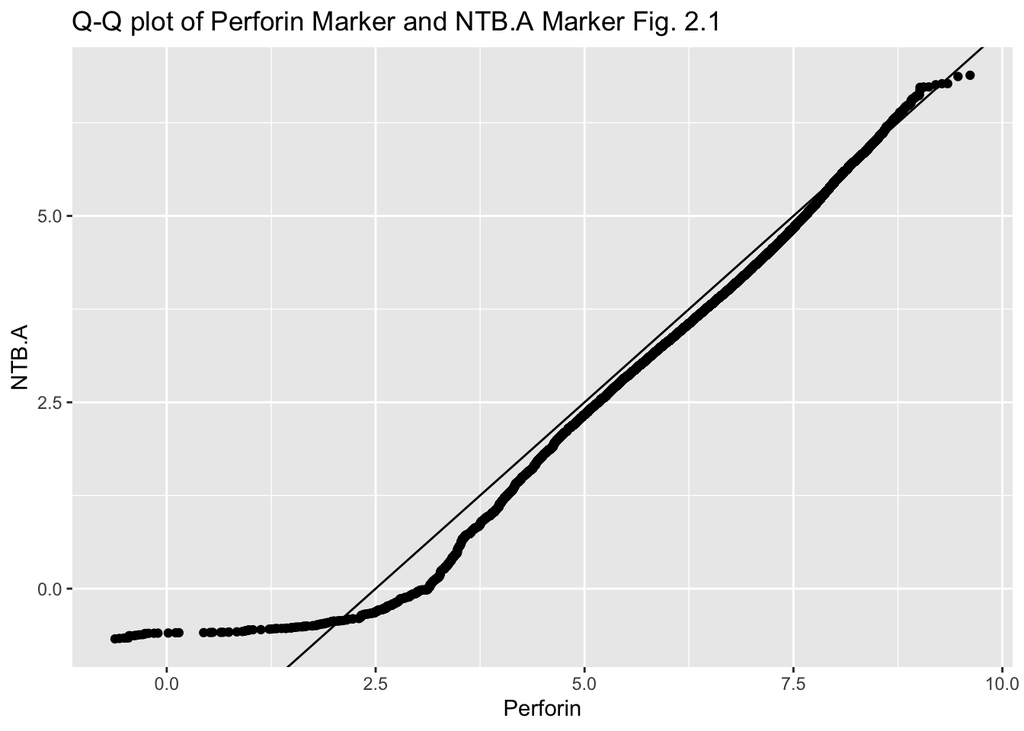

```r
qq.df = as.data.frame(qqplot(cytof$Perforin, cytof$NTB.A,plot.it = FALSE))
ggplot(qq.df, aes(x = x, y = y)) + geom_point() + geom_abline(aes(slope=1, intercept=-2.5)) +
  ggtitle("Q-Q plot of Perforin Marker and NTB.A Marker Fig. 2.1") +
  xlab("Perforin") + ylab("NTB.A")
```

From the data Perforin and NTB.A we can see that the distribution is similar as the first part falls in one straight line. the middle part also falls in one straight line. The last part doesn’t falls in straight line. i feel the plot is simple.

## Question 3

```r
summary(cytof)
```

```
##      NKp30            KIR3DL1             NKp44            KIR2DL1
##  Min.   :-0.6733   Min.   :-0.67380   Min.   :-0.6739   Min.   :-0.6739
##  1st Qu.: 2.8238   1st Qu.:-0.35515   1st Qu.:-0.2904   1st Qu.:-0.1282
##  Median : 3.7796   Median :-0.02122   Median : 0.7593   Median : 1.7049
##  Mean   : 3.5948   Mean   : 1.05674   Mean   : 1.2652   Mean   : 1.7765
##  3rd Qu.: 4.5907   3rd Qu.: 2.15491   3rd Qu.: 2.6436   3rd Qu.: 3.2782
##  Max.   : 7.8212   Max.   : 7.36360   Max.   : 7.2905   Max.   : 7.9213
##    GranzymeB          CXCR6              CD161            KIR2DS4
##  Min.   :-0.672   Min.   :-0.67376   Min.   :-0.6738   Min.   :-0.6739
##  1st Qu.: 2.951   1st Qu.:-0.36745   1st Qu.:-0.2929   1st Qu.:-0.2043
##  Median : 3.683   Median :-0.05814   Median : 0.7257   Median : 1.7103
##  Mean   : 3.457   Mean   : 0.54687   Mean   : 1.0596   Mean   : 1.7629
##  3rd Qu.: 4.242   3rd Qu.: 1.35477   3rd Qu.: 2.3461   3rd Qu.: 3.4708
##  Max.   : 6.185   Max.   : 4.76702   Max.   : 5.6971   Max.   : 6.5207
##      NKp46             NKG2D             NKG2C               X2B4
##  Min.   :-0.6721   Min.   :-0.6736   Min.   :-0.67387   Min.   :-0.6739
##  1st Qu.: 3.0094   1st Qu.: 1.2433   1st Qu.:-0.38872   1st Qu.:-0.2154
##  Median : 3.8535   Median : 2.6266   Median :-0.09717   Median : 1.0444
##  Mean   : 3.5701   Mean   : 2.3635   Mean   : 0.60702   Mean   : 1.1576
##  3rd Qu.: 4.4796   3rd Qu.: 3.5503   3rd Qu.: 1.47588   3rd Qu.: 2.3652
##  Max.   : 6.6703   Max.   : 6.8310   Max.   : 6.78993   Max.   : 5.0679
##       CD69           KIR3DL1.S1            CD2             KIR2DL5
##  Min.   :-0.6611   Min.   :-0.67390   Min.   :-0.6739   Min.   :-0.6738
##  1st Qu.: 3.8747   1st Qu.:-0.38403   1st Qu.: 2.2902   1st Qu.: 1.2697
##  Median : 4.5885   Median :-0.09276   Median : 3.9454   Median : 2.4158
##  Mean   : 4.5058   Mean   : 0.73871   Mean   : 3.4134   Mean   : 2.1593
##  3rd Qu.: 5.2523   3rd Qu.: 1.65773   3rd Qu.: 4.8724   3rd Qu.: 3.1928
##  Max.   : 8.0455   Max.   : 6.26132   Max.   : 7.7211   Max.   : 5.7212
##      DNAM.1            CD4               CD8               CD57
##  Min.   :0.8563   Min.   :-0.6739   Min.   :-0.6738   Min.   :-0.6735
##  1st Qu.:1.0443   1st Qu.:-0.4379   1st Qu.: 0.2508   1st Qu.: 0.8916
##  Median :1.3535   Median :-0.2036   Median : 2.4007   Median : 3.0709
##  Mean   :1.5843   Mean   : 0.2869   Mean   : 2.2130   Mean   : 2.5780
##  3rd Qu.:1.8796   3rd Qu.: 0.6275   3rd Qu.: 3.7001   3rd Qu.: 4.1450
##  Max.   :8.7841   Max.   : 4.9322   Max.   : 7.4813   Max.   : 6.6852
##      TRAIL            KIR3DL2             MIP1b             CD107a
##  Min.   :-0.6739   Min.   :-0.67390   Min.   :-0.6737   Min.   :-0.6739
##  1st Qu.:-0.4084   1st Qu.:-0.35674   1st Qu.: 2.3758   1st Qu.:-0.3994
##  Median :-0.1442   Median :-0.03381   Median : 3.2699   Median :-0.1223
##  Mean   : 0.4736   Mean   : 0.77490   Mean   : 3.0124   Mean   : 0.6076
```

[output cut: 8 more lines]

```
##  Max.   : 5.0265   Max.   : 7.5307   Max.   : 8.2290   Max.   : 4.129952
##     Perforin       KIR2DL2.L3.S2        KIR2DL3            NKG2A
##  Min.   :-0.6189   Min.   :-0.6739   Min.   :-0.6739   Min.   :-0.6733
##  1st Qu.: 6.5303   1st Qu.:-0.3990   1st Qu.:-0.3910   1st Qu.: 2.5479
##  Median : 7.1411   Median :-0.1301   Median :-0.1020   Median : 3.8345
##  Mean   : 6.9619   Mean   : 0.5516   Mean   : 0.7100   Mean   : 3.6444
##  3rd Qu.: 7.5950   3rd Qu.: 1.3537   3rd Qu.: 1.7530   3rd Qu.: 5.0034
##  Max.   : 9.6139   Max.   : 5.8729   Max.   : 6.4319   Max.   : 8.1448
##      NTB.A              CD56             INFg
##  Min.   :-0.6737   Min.   :-0.645   Min.   :-0.6735
##  1st Qu.: 3.8259   1st Qu.: 5.051   1st Qu.: 1.0488
##  Median : 4.4428   Median : 5.711   Median : 2.2654
##  Mean   : 4.3019   Mean   : 5.715   Mean   : 2.0348
##  3rd Qu.: 4.9508   3rd Qu.: 6.401   3rd Qu.: 3.1019
##  Max.   : 6.8866   Max.   : 9.267   Max.   : 7.6256
```

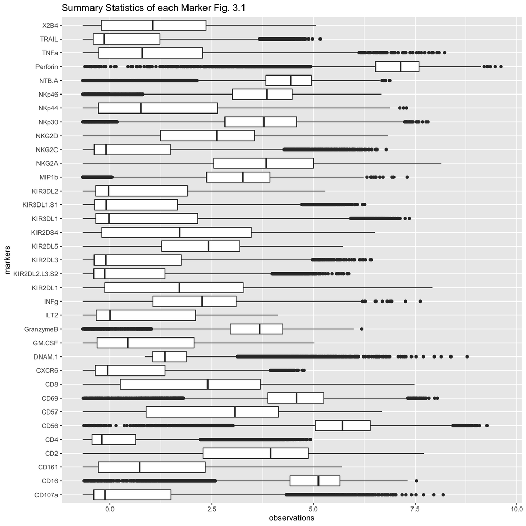

```r
cytof %>% pivot_longer(colnames(cytof), names_to = "markers", values_to = "observations") %>% ggplot(aes(x = observations, y = markers)) +
  geom_boxplot() +
  ggtitle("Summary Statistics of each Marker Fig. 3.1")
```

We can clearly see from the box plot that majority markers have maximum outliers. I feel that the box plot has all the data from the summary function and it would be very difficult to understand the center and spread of each marker just with a summary function. The box plot gives a more clear idea of the center and spread of the data. In density plots we cannot see the outliers (Fig.1.1) whereas in boxplot we can see the center, spread and get a clear idea of the outliers.